# Football Matches 2024/2025 - KPI Analysis

David Kang

2025-10-02

## Introduction

This report analyzes a dataset of 1941 football matches from the 2024/2025 season across Europe’s top five leagues (Premier League, La Liga, Serie A, Bundesliga, Ligue 1) and the UEFA Champions League. The dataset includes match dates, stadiums, referees, results, and derived statistics such as goal difference and match outcome.

The objective of this analysis is to explore key performance indicators (KPIs) at both the league and team level. Specifically, we will examine:

Home vs away winning percentages.

The distribution of final scores.

Team-level performance summaries.

Regression analysis of match outcomes.

## League Summary Plots

League Summary KPIs

| competition_name | total_matches | avg_goals | home_win_pct | away_win_pct | draw_pct |
| --- | --- | --- | --- | --- | --- |
| Bundesliga | 306 | 3.133987 | 38.56209 | 36.27451 | 25.16340 |
| La Liga | 380 | 2.618421 | 44.47368 | 30.00000 | 25.52632 |
| Ligue 1 | 306 | 2.977124 | 46.73203 | 33.00654 | 20.26144 |
| Premier League | 380 | 2.934210 | 40.78947 | 34.73684 | 24.47368 |
| Serie A | 380 | 2.560526 | 39.73684 | 31.84211 | 28.42105 |
| UEFA Champions League | 189 | 3.328042 | 50.79365 | 35.44974 | 13.75661 |

Table 1. The table shows each league’s average goals per match and the percentage of games that ended in home wins, away wins, or draws.

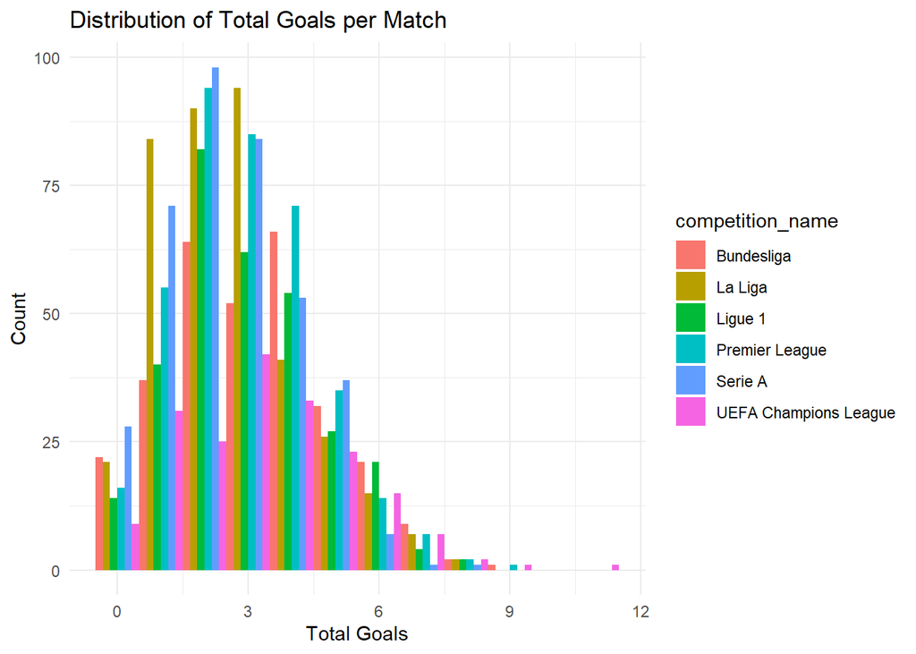

Figure 1. This histogram shows how often matches end with different total goal counts.

# Team-Level KPIs

Team-Level KPIs

| competition_name | home_team | matches_played | goals_scored | avg_goal_diff |
| --- | --- | --- | --- | --- |
| Bundesliga | 1. FC Heidenheim 1846 | 17 | 46 | -1.1764706 |
| Bundesliga | 1. FC Union Berlin | 17 | 41 | -0.2941176 |
| Bundesliga | 1. FSV Mainz 05 | 17 | 42 | 0.3529412 |
| Bundesliga | Bayer 04 Leverkusen | 17 | 58 | 0.8235294 |
| Bundesliga | Borussia Dortmund | 17 | 63 | 1.4705882 |
| Bundesliga | Borussia Mönchengladbach | 17 | 55 | 0.1764706 |
| Bundesliga | Eintracht Frankfurt | 17 | 63 | 1.1176471 |
| Bundesliga | FC Augsburg | 17 | 38 | -0.1176471 |
| Bundesliga | FC Bayern München | 17 | 69 | 2.1764706 |
| Bundesliga | FC St. Pauli 1910 | 17 | 29 | -0.5294118 |
| Bundesliga | Holstein Kiel | 17 | 65 | -1.0000000 |
| Bundesliga | RB Leipzig | 17 | 56 | 0.5882353 |
| Bundesliga | SC Freiburg | 17 | 58 | 0.3529412 |
| Bundesliga | SV Werder Bremen | 17 | 47 | -0.2941176 |
| Bundesliga | TSG 1899 Hoffenheim | 17 | 61 | -0.6470588 |
| Bundesliga | VfB Stuttgart | 17 | 62 | 0.4705882 |
| Bundesliga | VfL Bochum 1848 | 17 | 49 | -1.0000000 |
| Bundesliga | VfL Wolfsburg | 17 | 57 | -0.1764706 |
| La Liga | Athletic Club | 19 | 45 | 1.0000000 |
| La Liga | CA Osasuna | 19 | 56 | 0.5263158 |
| La Liga | CD Leganés | 19 | 50 | -0.2105263 |
| La Liga | Club Atlético de Madrid | 19 | 57 | 1.4210526 |
| La Liga | Deportivo Alavés | 19 | 31 | -0.1578947 |
| La Liga | FC Barcelona | 19 | 72 | 1.6842105 |
| La Liga | Getafe CF | 19 | 34 | -0.2105263 |
| La Liga | Girona FC | 19 | 57 | -0.1578947 |
| La Liga | RC Celta de Vigo | 19 | 53 | 0.5789474 |
| La Liga | RCD Espanyol de Barcelona | 19 | 43 | 0.1578947 |
| La Liga | RCD Mallorca | 19 | 41 | -0.0526316 |
| La Liga | Rayo Vallecano de Madrid | 19 | 50 | -0.1052632 |

[output cut: 102 more lines]

Table 2. This table shows club-specific KPIs such as goals scored and average goal difference.

# Goal Summary Table

[output not shown]

<sup>1</sup> Median (Q1, Q3)

# Regression Analysis

| **Characteristic** | **OR** | **95% CI** | **p-value** |
| --- | --- | --- | --- |
| fulltime_home | 5.96 | 5.11, 7.02 | <0.001 |

Abbreviations: CI = Confidence Interval, OR = Odds Ratio

Regression Table. This logistic regression estimates the effect of home goal advantage on the likelihood of a home win.

# Conclusion

This report provides a structured analysis of the 2024/25 football season across Europe’s top leagues. We observed differences in average goals, home/away performances, and team-level KPIs. The regression analysis illustrates how modeling can provide further insights into match outcomes.